# C6 · ¿Cómo obtiene y utiliza energía un animal?

Práctica guiada de fisiología con R y fauna silvestre

Autor/a

Material docente de Fisiología

**NotaUna pregunta para toda la práctica**

Si un animal dispone de menos alimento y gasta más energía, ¿qué ocurre con sus reservas? Antes de responder, aprenderemos a medir una tasa y a construir un balance.

**Nivel:** licenciatura, primeros pasos con R. **Duración sugerida:** 100 minutos. **Modalidad:** parejas, con conclusión individual. **Requisitos:** operaciones aritméticas y conceptos de ATP y metabolismo de C6. No se requiere experiencia con modelos estadísticos.

**Todos los datos son simulados.** Los animales son hipotéticos y no representan valores normales de una especie. Es una práctica de computadora; no requiere manipular animales. Los resultados no son recomendaciones alimentarias ni protocolos experimentales.

## Lo que podrás hacer

Al terminar esta sesión podrás:

1. Calcular el consumo de oxígeno de un pez corrigiendo el consumo de fondo y la masa.
2. Distinguir una tasa de consumo de una cantidad de energía o una reserva.
3. Resolver un presupuesto energético y explicar cuándo se acumulan o movilizan reservas.
4. Modificar un supuesto y justificar una predicción con una gráfica y sus límites.

| Momento | Actividad | Tiempo |
| --- | --- | --- |
| Preparación | Abrir el proyecto, asignar valores y hacer una predicción | 10 min |
| Ejercicio 1 | Consumo de oxígeno de un pez | 30 min |
| Ejercicio 2 | Presupuesto energético de un roedor | 35 min |
| Reto | Cambiar ingestión y gasto; explicar el resultado | 15 min |
| Cierre | Revisar unidades, entregar y discutir límites | 10 min |

El complemento sobre temperatura es opcional y añade 10 minutos.

## Antes de empezar

Abre `C6_metabolismo.Rproj` en RStudio. Puedes trabajar de dos maneras:

- **Cuaderno:** abre este `.qmd` y ejecuta cada bloque, de arriba hacia abajo. Pulsa **Render** para generar el informe HTML. Esta opción necesita Quarto, `knitr` y `rmarkdown`.
- **Solo R:** abre `C6_metabolismo.R` y ejecuta sus secciones con **Ctrl + Enter**. No necesita paquetes adicionales. El script también puede ejecutarse completo con `source("C6_metabolismo.R", encoding = "UTF-8")` y guarda tres gráficas en un PDF.

El archivo `C6_metabolismo.html` ya preparado se puede leer en un navegador sin R. No ejecuta código: para modificar cálculos usa el `.qmd` o el `.R`.

En R, `<-` guarda un valor; `#` inicia un comentario; `c()` reúne valores y `$` selecciona una columna. Usa punto decimal: `0.5`, no `0,5`. Ejecutar una línea vuelve a calcularla: después de cambiar un dato, vuelve a ejecutar los bloques que lo utilizan.

```r
# Crea las carpetas de salida si todavía no existen.
dir.create("datos", showWarnings = FALSE)
dir.create("resultados", showWarnings = FALSE)
options(width = 90)

# Una primera operación: pasar de gramos a kilogramos.
masa_g <- 10
masa_kg <- masa_g / 1000
print(masa_kg)
```

```
[1] 0.01
```

**Predicción inicial:** escribe una oración sobre lo que esperas que ocurra con las reservas si disminuye la ingestión. Al final volverás a ella.

## Ejercicio 1 · ¿Cuánto oxígeno consume un pez?

### El escenario

Un pez de **10 g** permanece, de manera hipotética, en una cámara con **2 L de agua efectivos**. Ese volumen ya descuenta el volumen desplazado por el animal. Se simula un intervalo cerrado de una hora, a temperatura constante y con mezcla suficiente. Un **blanco**, bajo condiciones comparables pero sin pez, permite estimar el consumo de oxígeno del sistema.

La concentración de oxígeno disminuye con el tiempo. Primero calcularemos la pendiente de esa disminución; después descontaremos el blanco. La relación con C6 es que el oxígeno participa como aceptor final de electrones en la respiración aeróbica, pero su consumo **no mide directamente moléculas de ATP** ni toda la contribución anaerobia.

### Paso 1. Construye los datos

Usamos líneas ideales para que se vea con claridad el cálculo. No añadimos ruido aleatorio; por eso no hace falta una semilla. En un experimento real habría variación y se revisaría la calidad del registro.

```r
# seq() produce 0, 10, 20, ..., 60 minutos.
tiempo_min <- seq(0, 60, by = 10)
tiempo_h <- tiempo_min / 60

# Disminuciones SIMULADAS: sistema 0.30 y blanco 0.05 mg O2/L/h.
# data.frame() organiza las columnas en una tabla.
oxigeno <- data.frame(
  tiempo_min = tiempo_min,
  tiempo_h = tiempo_h,
  sistema_mg_L = 8 - 0.30 * tiempo_h,
  blanco_mg_L = 8 - 0.05 * tiempo_h
)
print(oxigeno)
```

```
  tiempo_min  tiempo_h sistema_mg_L blanco_mg_L
1          0 0.0000000         8.00    8.000000
2         10 0.1666667         7.95    7.991667
3         20 0.3333333         7.90    7.983333
4         30 0.5000000         7.85    7.975000
5         40 0.6666667         7.80    7.966667
6         50 0.8333333         7.75    7.958333
7         60 1.0000000         7.70    7.950000
```

```r
# Exporta los mismos datos que acabas de crear.
write.csv(oxigeno, "datos/oxigeno_simulado.csv", row.names = FALSE)
```

**Antes de graficar:** ¿en cuál de las dos series esperas una caída más pronunciada? Explica por qué la disminución del blanco no debe atribuirse al pez.

### Paso 2. Mira la pendiente

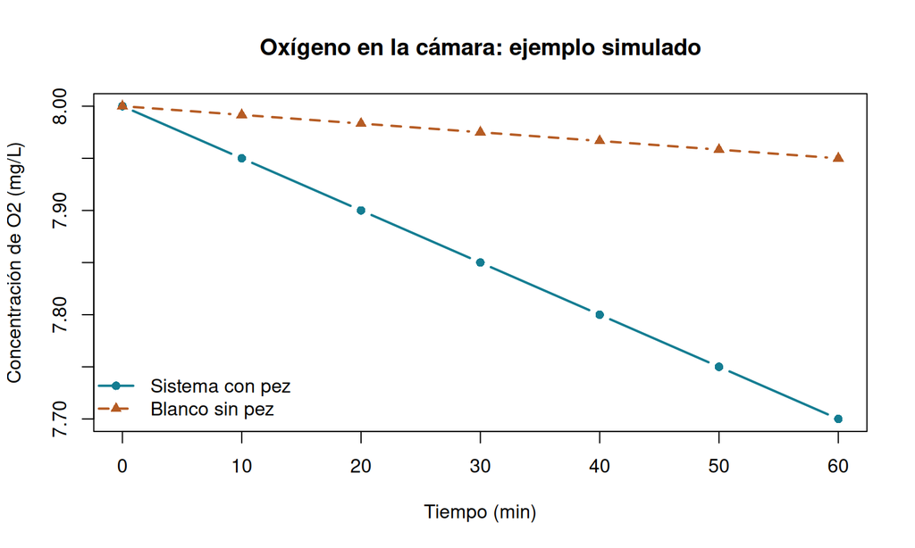

Figura 1: Datos simulados. La caída del sistema incluye al pez y al consumo de fondo.

```r
# type = "b" dibuja puntos y líneas. Las formas también distinguen series.
plot(oxigeno$tiempo_min, oxigeno$sistema_mg_L,
     type = "b", pch = 16, col = "#147D92", lwd = 2,
     ylim = range(oxigeno$sistema_mg_L, oxigeno$blanco_mg_L),
     xlab = "Tiempo (min)", ylab = "Concentración de O2 (mg/L)",
     main = "Oxígeno en la cámara: ejemplo simulado")
lines(oxigeno$tiempo_min, oxigeno$blanco_mg_L,
      type = "b", pch = 17, col = "#B65C24", lty = 2, lwd = 2)
legend("bottomleft", c("Sistema con pez", "Blanco sin pez"),
       col = c("#147D92", "#B65C24"), pch = c(16, 17),
       lty = c(1, 2), lwd = 2, bty = "n")
```

El eje vertical muestra **concentración**, no consumo total. La gráfica empieza cerca de 7.7 mg/L para apreciar la pequeña caída; no representa una pérdida de todo el oxígeno.

### Paso 3. De pendiente a tasa

`lm(y ~ x)` ajusta una recta: pregunta cuánto cambia `y` al aumentar `x`. `coef(modelo)[2]` extrae su pendiente. Aquí usamos **horas** para obtener mg O₂/L/h. Solo utilizamos la pendiente descriptiva; estos registros repetidos de un individuo no son réplicas biológicas independientes.

```r
# Ajusta concentración en función del tiempo medido en horas.
modelo_sistema <- lm(sistema_mg_L ~ tiempo_h, data = oxigeno)
modelo_blanco <- lm(blanco_mg_L ~ tiempo_h, data = oxigeno)

# Las pendientes son negativas. El signo menos las convierte en descensos positivos.
descenso_sistema <- -unname(coef(modelo_sistema)[2])
descenso_blanco <- -unname(coef(modelo_blanco)[2])

volumen_efectivo_L <- 2
masa_g <- 10
masa_kg <- masa_g / 1000

# (mg O2/L/h) * L = mg O2/h atribuibles al animal.
consumo_total_mg_h <- (descenso_sistema - descenso_blanco) * volumen_efectivo_L

# (mg O2/h) / kg = mg O2/kg/h.
consumo_especifico_mg_kg_h <- consumo_total_mg_h / masa_kg

resultado_oxigeno <- data.frame(
  descenso_sistema_mg_L_h = descenso_sistema,
  descenso_blanco_mg_L_h = descenso_blanco,
  consumo_total_mg_h = consumo_total_mg_h,
  consumo_especifico_mg_kg_h = consumo_especifico_mg_kg_h
)
print(round(resultado_oxigeno, 3))
```

```
  descenso_sistema_mg_L_h descenso_blanco_mg_L_h consumo_total_mg_h
1                     0.3                   0.05                0.5
  consumo_especifico_mg_kg_h
1                         50
```

```r
write.csv(resultado_oxigeno, "resultados/consumo_oxigeno.csv", row.names = FALSE)
```

Comprueba a mano: **2 × (0.30 − 0.05) = 0.50 mg O₂/h**. Al dividir entre **0.010 kg** obtienes **50 mg O₂/kg/h**.

**ImportanteQué significa y qué no significa**

Es una tasa del intervalo simulado. No podemos llamarla metabolismo estándar solo porque el pez parezca inmóvil: faltan condiciones como estado posabsortivo y aclimatación. Tampoco podemos inferir ATP exacto, tolerancia a hipoxia o una tasa diaria constante.

### Tu turno · preguntas 1 y 2

1. Si omites el blanco, ¿cuánto consumo total estimas y en cuánto lo sobreestimas, en mg O₂/h y en porcentaje respecto al valor corregido?
2. Cambia únicamente `masa_g <- 20` y vuelve a ejecutar el bloque de tasa. ¿Qué ocurre con la tasa total y con la tasa por kilogramo? **Es un ejercicio de denominador:** conservar la misma pendiente no predice cómo respiraría un pez real de mayor tamaño. Restablece 10 g antes de continuar.

No conviertas los **mg** de O₂ directamente en **L** con un factor energético: necesitarías una conversión físico-química y condiciones del gas.

## Ejercicio 2 · ¿Alcanza la energía para mantener reservas?

### El escenario

Un roedor silvestre hipotético ingiere 300 kJ en un día. Parte de esa energía se pierde en heces y orina. El resto cubre el gasto metabólico, la producción y el cambio de reservas. Comparamos ese escenario con otro de menor ingestión. **Todos los términos se refieren a un día.**

| Símbolo | Significado | Unidad |
| --- | --- | --- |
| I | Energía ingerida | kJ/día |
| F | Energía perdida en heces | kJ/día |
| U | Energía perdida en orina | kJ/día |
| G | Energía perdida en gases combustibles; aquí se fija en 0 | kJ/día |
| EM | Energía metabolizable: I − F − U − G | kJ/día |
| M | Gasto metabólico: mantenimiento, actividad, termorregulación y digestión | kJ/día |
| P | Energía retenida en crecimiento estructural o transferida a productos reproductivos | kJ/día |
| ΔE | Cambio de reservas: EM − M − P | kJ/día |

Esta convención separa **P** de las reservas para evitar doble conteo. El costo metabólico de sintetizar tejidos está en M; su energía retenida está en P.

### Paso 4. Calcula entradas, pérdidas y reservas

```r
# Cada fila representa un escenario didáctico, no un animal muestreado.
presupuesto <- data.frame(
  escenario = c("Inicial", "Menor ingestión"),
  I_kJ_dia = c(300, 240),
  F_kJ_dia = c(60, 60),
  U_kJ_dia = c(15, 15),
  G_kJ_dia = c(0, 0),
  M_kJ_dia = c(180, 180),
  P_kJ_dia = c(20, 20)
)

# Guarda las entradas antes de añadir resultados.
write.csv(presupuesto, "datos/presupuesto_simulado.csv", row.names = FALSE,
          fileEncoding = "UTF-8")

# $ permite usar una columna y crear otra con los resultados de cada fila.
presupuesto$EM_kJ_dia <- presupuesto$I_kJ_dia - presupuesto$F_kJ_dia -
  presupuesto$U_kJ_dia - presupuesto$G_kJ_dia
presupuesto$reservas_kJ_dia <- presupuesto$EM_kJ_dia -
  presupuesto$M_kJ_dia - presupuesto$P_kJ_dia
print(presupuesto)
```

```
        escenario I_kJ_dia F_kJ_dia U_kJ_dia G_kJ_dia M_kJ_dia P_kJ_dia EM_kJ_dia
1         Inicial      300       60       15        0      180       20       225
2 Menor ingestión      240       60       15        0      180       20       165
  reservas_kJ_dia
1              25
2             -35
```

```r
write.csv(presupuesto, "resultados/balance_energetico.csv", row.names = FALSE,
          fileEncoding = "UTF-8")
```

### Paso 5. Interpreta el signo

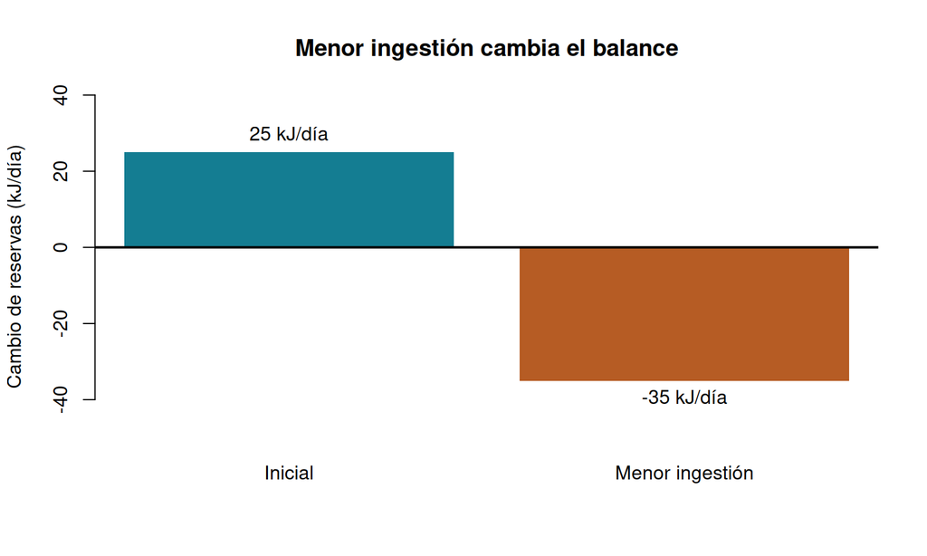

Figura 2: Simulación: se mantienen F, U, G, M y P constantes y solo cambia I.

```r
# Incluye siempre el cero: permite comparar acumulación y movilización.
limites <- range(c(0, presupuesto$reservas_kJ_dia)) + c(-15, 15)
barras <- barplot(presupuesto$reservas_kJ_dia,
                  names.arg = presupuesto$escenario,
                  col = c("#147D92", "#B65C24"), border = NA,
                  ylim = limites, ylab = "Cambio de reservas (kJ/día)",
                  main = "Menor ingestión cambia el balance")
abline(h = 0, lwd = 2)
text(barras, presupuesto$reservas_kJ_dia,
     labels = paste(presupuesto$reservas_kJ_dia, "kJ/día"),
     pos = ifelse(presupuesto$reservas_kJ_dia >= 0, 3, 1))
```

**ΔE > 0:** acumulación de reservas. **ΔE < 0:** movilización de reservas para cerrar el balance, mientras existan reservas disponibles y se mantengan estos supuestos. **ΔE = 0:** no hay cambio neto de reservas en el intervalo.

No es una predicción de pérdida de peso ni significa supervivencia indefinida. F y U podrían cambiar con la ingestión; M y P también podrían ajustarse. Mantenerlos constantes aquí sirve para aislar una relación matemática.

### Tu turno · preguntas 3 y 4

3. Escribe los valores de EM y ΔE de ambos escenarios. ¿Por qué una reserva negativa no significa que la energía ingerida sea negativa?
4. ¿Cuánta energía debe ingerir el animal para que ΔE = 0 si se mantienen F = 60, U = 15, G = 0, M = 180 y P = 20 kJ/día? Resuelve la ecuación y compruébala con R.

## Reto · Menos alimentación y mayor actividad

Imagina que una perturbación reduce el tiempo de forrajeo y aumenta los desplazamientos. Esto es una **hipótesis**, no una observación sobre una población. Modifica los dos parámetros del bloque y calcula la predicción antes de ejecutarlo.

```r
# CAMBIA AQUÍ: proporción de reducción de ingestión (0.20 significa 20 %).
reduccion_ingesta <- 0.20
# CAMBIA AQUÍ: incremento del gasto en kJ/día, NO en porcentaje.
aumento_gasto_kJ_dia <- 30

# Comprueba que las entradas representen este escenario.
stopifnot(reduccion_ingesta >= 0, reduccion_ingesta <= 1,
          aumento_gasto_kJ_dia >= 0)

I_reto <- 300 * (1 - reduccion_ingesta)
M_reto <- 180 + aumento_gasto_kJ_dia
EM_reto <- I_reto - 60 - 15 - 0
reservas_reto <- EM_reto - M_reto - 20

resultado_reto <- data.frame(
  reduccion_ingesta = reduccion_ingesta,
  aumento_gasto_kJ_dia = aumento_gasto_kJ_dia,
  I_kJ_dia = I_reto, M_kJ_dia = M_reto,
  EM_kJ_dia = EM_reto, reservas_kJ_dia = reservas_reto
)
print(resultado_reto)
```

```
  reduccion_ingesta aumento_gasto_kJ_dia I_kJ_dia M_kJ_dia EM_kJ_dia reservas_kJ_dia
1               0.2                   30      240      210       165             -65
```

```r
write.csv(resultado_reto, "resultados/reto.csv", row.names = FALSE)
```

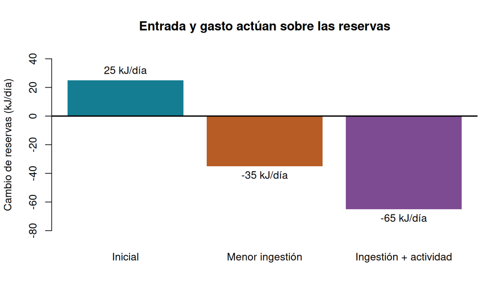

Figura 3: Comparación de tres escenarios simulados; la línea horizontal marca balance de reservas cero.

```r
valores_reto <- c(presupuesto$reservas_kJ_dia, reservas_reto)
barras_reto <- barplot(valores_reto,
  names.arg = c("Inicial", "Menor ingestión", "Ingestión + actividad"),
  col = c("#147D92", "#B65C24", "#7D4B91"), border = NA,
  ylim = range(c(0, valores_reto)) + c(-20, 20),
  ylab = "Cambio de reservas (kJ/día)",
  main = "Entrada y gasto actúan sobre las reservas")
abline(h = 0, lwd = 2)
text(barras_reto, valores_reto, labels = paste(valores_reto, "kJ/día"),
     pos = ifelse(valores_reto >= 0, 3, 1))
```

### Tu turno · preguntas 5 y 6

5. Con los valores iniciales del reto, ¿cuánto vale ΔE y cuánto cambia respecto al escenario inicial? Prueba después una reducción de 10 % y un incremento de gasto de 10 kJ/día. Guarda ambos resultados en tus respuestas e identifica el efecto de cambiar cada término.
6. Propón **una respuesta fisiológica o conductual posible**, explica un costo asociado y señala **dos datos reales** que necesitarías medir antes de concluir que ocurre en una especie. No deduzcas mortalidad ni pérdida de gramos de tejido con este modelo.

## Entrega y criterios

Entrega una carpeta `C6_Apellido_Nombre` con:

1. Tu `.qmd` o `.R` comentado, con los parámetros finales que utilizaste.
2. Las seis respuestas, incluida la predicción inicial revisada, en `respuestas_C6.md` (plantilla incluida).
3. Un HTML renderizado o el PDF de gráficas generado por el script. Incluye la tabla `resultados/reto.csv` y anota en las respuestas los dos escenarios del reto.

La fecha y plataforma de entrega las indicará el docente. Esta práctica propone **evaluación formativa**, sin modificar ponderaciones del curso.

| Criterio de revisión | Evidencia observable |
| --- | --- |
| Cálculo reproducible | El código corre en orden y coincide con las tablas entregadas |
| Unidades y corrección | Distingue mg/L, mg/h y mg/kg/h; descuenta el blanco |
| Balance energético | Calcula EM y ΔE sin contar dos veces pérdidas o gasto |
| Interpretación | Explica el signo, las diferencias y un mecanismo plausible |
| Límites | Identifica simulación y supuestos; propone dos mediciones reales |

**Pregunta de salida:** explica en dos frases por qué un animal puede mantener casi constante su concentración de ATP mientras aumenta su tasa metabólica.

## Complemento opcional · Temperatura y metabolismo

Este ejercicio recupera la curva conceptual de C6. Es un ectotermo hipotético; no representa el intervalo tolerado por una especie. No se desarrolla Q₁₀, reservado para el tema de temperatura.

```r
# Ejecuta estas líneas solo si tienes tiempo adicional.
temperatura_C <- c(15, 20, 25, 30)
tasa_mg_kg_h <- c(70, 100, 140, 200)
plot(temperatura_C, tasa_mg_kg_h, type = "b", pch = 16,
     col = "#147D92", lwd = 2,
     xlab = "Temperatura (°C)", ylab = "Consumo de O2 (mg/kg/h)",
     main = "Respuesta simulada dentro de un intervalo")
# ¿Qué sucede de 20 a 30 °C en ESTE conjunto de datos?
print(200 / 100)
```

¿Por qué no podemos prolongar esta curva hasta 50 °C ni usarla para fijar la temperatura de un recinto? Considera especie, aclimatación, actividad y límites fisiológicos.

## Fuentes y relación con el curso

- **Material de clase consultado:** *C6 Metabolismo y suministro de energía*, presentación del curso (42 diapositivas): respirometría, diapositivas 22–26; presupuestos, 32–39; temperatura, 29. Se mantienen sus valores didácticos para facilitar el paso de diapositivas a R.
- **Lectura central indicada en la presentación:** Willmer, P., Stone, G., & Johnston, I. (2005). *Environmental physiology of animals* (2nd ed.). Blackwell Publishing. Capítulo 6, especialmente secciones 6.5–6.6, pp. 126–139. Los datos de esta práctica no proceden de muestreos del libro.
- R Core Team. (s. f.). *Fitting linear models*. Documentación oficial de R. https://stat.ethz.ch/R-manual/R-devel/library/stats/html/lm.html. Se usa `lm()` únicamente para estimar la pendiente.
- Posit. (s. f.). *Using R*. Documentación de Quarto. https://quarto.org/docs/computations/r.html. Describe la ejecución de bloques R con knitr y la generación del documento.

Los escenarios, preguntas y código son material didáctico elaborado para esta práctica. No se realizan pruebas de significación ni inferencias poblacionales con los datos simulados.